# Insights For NFL Draft 2021

Marissa Troiano-Yang

4/19/2021

The 2021 NFL draft is less than two weeks away and we certainly have a plethora of information to make some high-quality data-driven predictions. But which variables should we focus on? After reviewing the 2020 season for each team, I thought it would be interesting to analyze which data significantly contributed to a team’s total number of wins for the season. With this information, a team could determine which aspects of their offense, defense, and special teams that they need to improve on and draft for in 2021. For the purpose of this blog, I will share my general process and outcomes of interest. To see more details and the code I used, check out my [GitHub!](https://github.com/mtroian1/Insights-For-NFL-Draft-2021)

# Approach:

- Analyze a lot of NFL data from 1970-2020
- Try to figure out some relationships between full-season stats (like total yards, total rushing yards, yards per play, etc)
- Build a linear regression to get the relationships between these variables and total wins
- Run some simulations for 2020 based on different scenarios that could have played out if those full-season stats were different (like if the Eagles had more receiving yards)

# Exploratory Graphs:

Here are some graphs related to the number of wins per team from regular season games between 1970-2020 that you might find interesting:

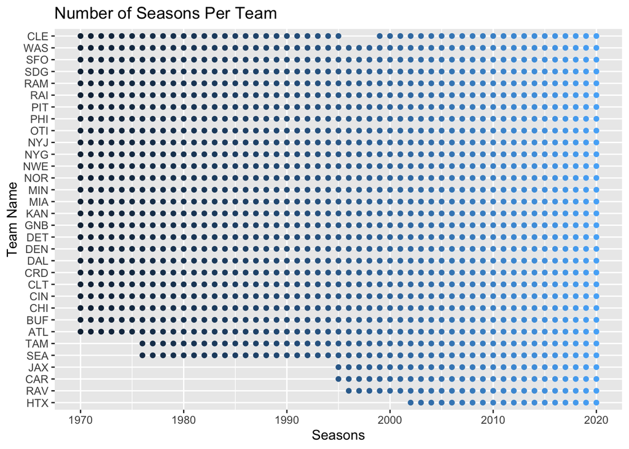

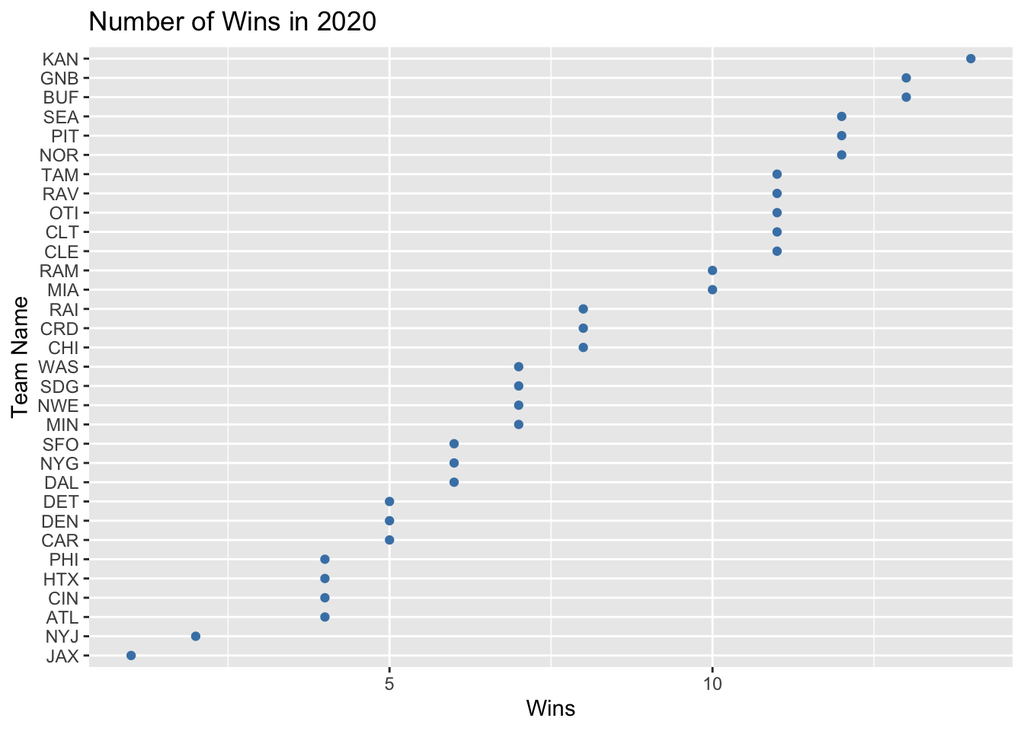

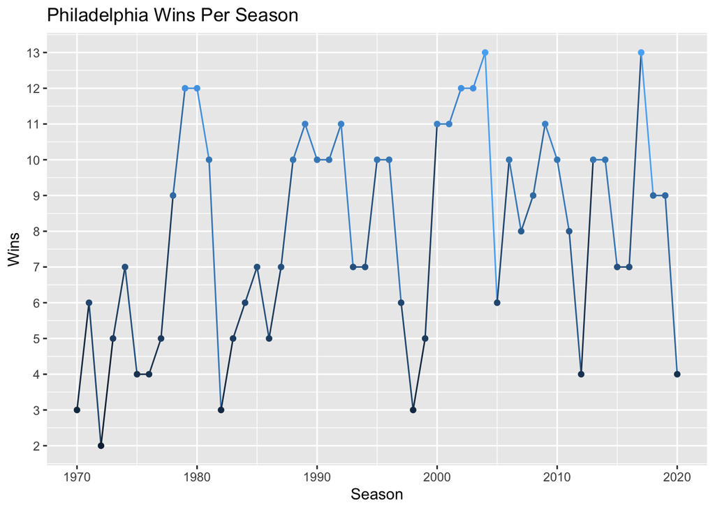

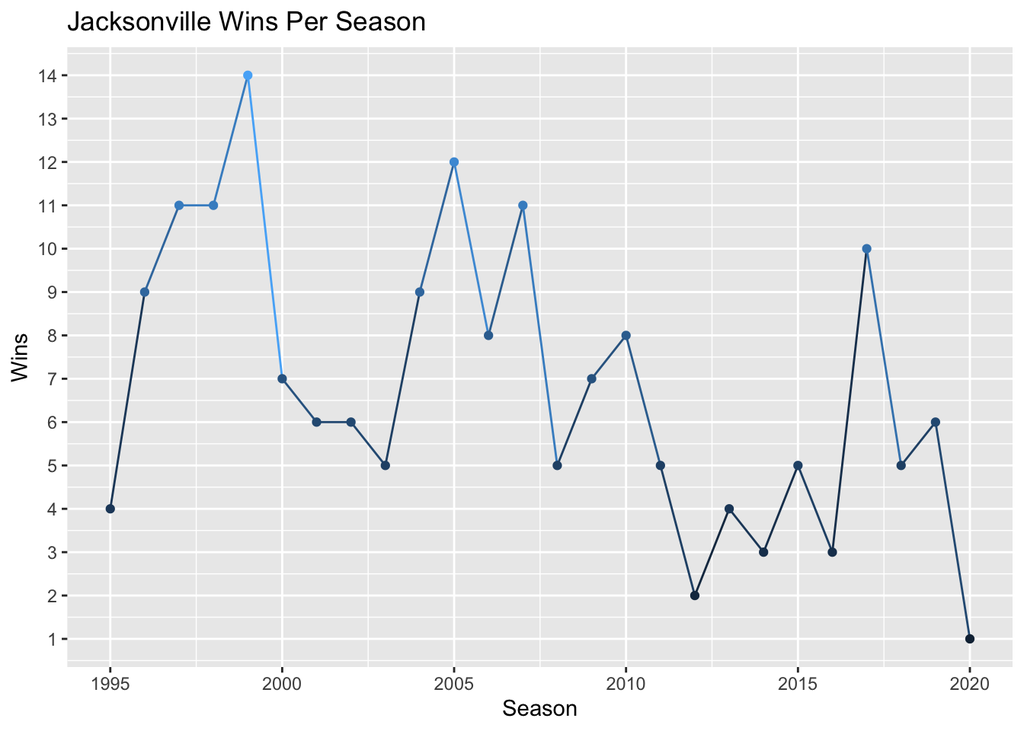

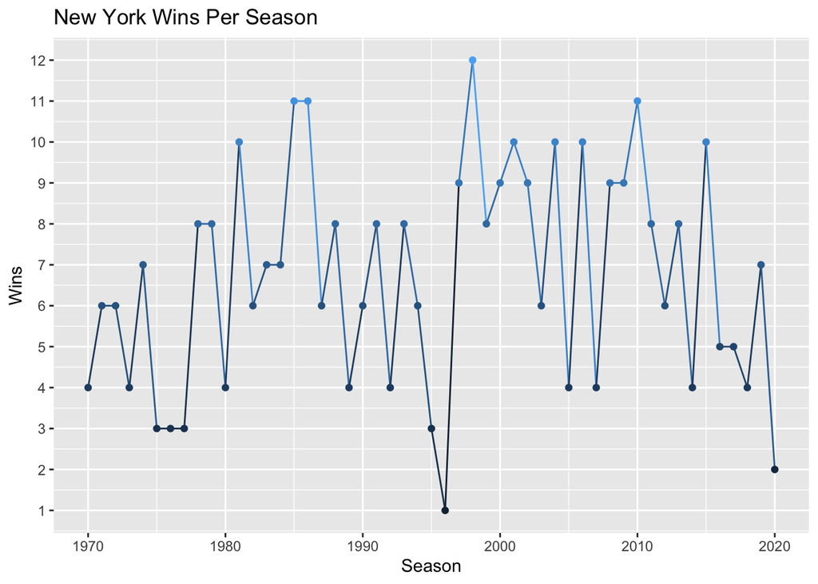

It is interesting to note that all three teams I will be discussing (Eagles, Jets, Jaguars) experienced a loss of 5 wins from 2019-2020. In 2020 the Jets had their second worst season in team’s history with their worst season in 1996 with only 1 win. They went from 7 wins to 2 wins in 1 year. Jacksonville didn’t fare much better with a 1 win season in 2020 after a 6 win season in 2019. These teams clearly need some of these insights! The Eagles dropped from 9 to 4 wins, with a very significant drop from 13 wins to 4 wins in just three years.

# Linear Regression Model

Let’s talk about linear regression. I chose to use a linear regression model to see which predictors would have a strong relationship with the number of wins for the 2020 NFL season. The predictors included over 40 variables ranging across the offense, defense, and special teams such as time of possession, passing yard, punting yards, and yards per play. I analyzed the linear regression model summary and determined that the model was a good fit for the data and could be used for prediction. Unsurprisingly there was indeed a relationship between all the predictors and the number of wins. I was excited to find several predictors with a strong relationship to the number of wins that are in line with what I would assume, given my understanding of football.

The final step was to apply the linear regression model to actual teams and make some predictions for 2020! I chose to analyze these teams because of their lack of wins for 2020: the Jacksonville Jaguars with 1 win, the New York Jets with 2 wins, and the Philadelphia Eagles with 4 wins. For most of the analysis, I only adjusted one predictor and kept all other variables the same to predict the number of wins the team could have achieved in 2020. Also, the predicted total number of wins is rounded to the nearest whole. Without further ado, here are the results!

# Important Note:

Each statistic analyzed below will have a small increase in the team’s total wins but combined, it could have a material impact. How all of these interact with each other is an exercise for a different day!

# Eagles:

#### Total Yards:

The Eagles 2020 total yards was 5,357, the league average was 5,746.5, and the team with highest amount of total yards in the league was 6,653. If the Eagles increased their total yards to 6,525 total yards, this increase could put the Eagles at 5 wins in 2020.

#### Receiving Yards:

The Eagles 2020 receiving yards was 3,709 and the league average was 4,045.75. If the Eagles increased their receiving yards to 4,000 and we adjust their total yards by 291 to reflect that increase (5,648), their total wins in 2020 could have been 6.

#### Rushing Attempts:

The Eagles 2020 had 403 rushing attempts. The league average was 423.84, and the team with the most rushing attempts for 2020 had 533. If the Eagles boosted their total rushing attempts for the season to 476 (an average of 24 rushing attempts per game), they could have seen an increase in total wins to 5. An increase to the 2020 league maximum rushing attempts of 533 (average of 31 attempts per game) could have led to 6 wins.

#### Yards Per Play

The Eagles’ 2020 yards per play (YPP) was 5.75 and the 2020 league average was 6. If the Eagles increased YPP to 6.7, they could have won 5 games in 2020. An increase of YPP to 7 could have led to 6 wins and an increase to 8 YPP could have led to 8 wins.

#### *Recommendations*:

The insights gathered from the linear regression model and analysis suggest that the Philadelphia Eagles should focus the 2021 season on the following:

- Increase total yards (passing and rushing) - The Eagles dumped Carson Wentz this off-season and it looks like Jalen Hurts is going to be the starting QB. Hurts did not have inspiring passing numbers in his starts last season and the Eagles likely need to rely on the run more this season. A healthy Miles Sanders (RB) (rank 15 with 867 rushing yards combined with Boston Scott, 59th rank with 374 rushing yards, and Jalen Hurts, 69th rank with 374 rushing yards gives them a lot of firepower on the ground for 2021.
- Increase receiving yards by drafting a strong receiver. Currently, the Eagle’s top four receivers include WR Travis Fulgham who ranks 82 with 539 receiving yards, TE Dallas Goedert who ranks 83 with 524 receiving yards, WR Greg Ward who ranks 110 with 419 receiving yards, and WR Jalen Reagor ranks 119 with 396 receiving yards. They could consider drafting Ja’Marr Chase from LSU, Jaylen Waddle from Alabama, DeVonta Smith from Alabama, or Rondale Moore from Purdue to help increase their receiving yards which will help Jalen Hurts and their win total in 2021.
- Increase rushing attempts of Miles Sanders and other current or drafted running backs.
- Increase yards-per-play. The Eagles had an uninspiring playbook in 2020 and didn’t really stretch the field. Adding one of those explosive wide receivers and using them on deeper routes will help the Eagles be in the playoff in 2021!

# Jacksonville:

#### Total Yards:

Jacksonville’s 2020 total yards were 5,227, well below league average. An increase of 519.5 to the league average of total yards (5,746.5) could have led to 3 wins and an increase to the highest number of total yards (6653) could lead to 4 wins.

#### Kicking Field Goals:

Jacksonville attempted 25 field goals and made 18. If they had made all 25, they could have 2.76 wins. This increases to 3 wins if they attempted and made 29 field goals. If this doesn’t sum up the Jags season last year, I’m not sure what does.

#### Kicking Extra Points:

Jacksonville had 36 total touchdowns in 2020. They attempted to kick 28 extra points but made 24, losing 4 points. With the other 8 touchdowns, they could have scored 16 points with two-point conversions. However, they only made 3 two-point conversions, losing an additional 10 points.

If Jacksonville went for 36 extra points and made them all, they could have 3 wins in 2020. Similarly, if they made all attempted 28 extra points AND all attempted 8 two-point conversions, they could have 3 wins for 2020.

The takeaway here, the conversion rate of your extra points matters and Jacksonville needs to do better next year.

#### Receiving Yards:

Jacksonville’s 2020 total receiving yards was 3927. If they increased their receiving yards by 118.75 to reach the league average of 4045.75, they could have seen an increase to 3.58 wins. If they increased receiving yards by 1078 to match the best team for the 2020 season, they could have seen 13 wins!!!

#### Yards Per Play:

Jacksonville’s average yards per play (YPP) for 2020 was 5.79. An increase to the league’s average of 6 YPP could have led to 3 wins and an increase to the highest YPP (7.09) could have led to 5 wins.

#### *Recommendations*:

- Draft Trevor Lawrence
- Increase rushing attempts with a second string running back. Jacksonville has RB James Robinson who ranks 5 with 1070 rushing yards/ 240 rushing attempts, QB Gardner Minshew II who ranks 106 with 153 yards / 29 attempts, and RB Dare Ogunbowale who ranks 110 with 143 yards / 32 attempts. They could consider drafting Travis Etienne from Clemson, Najee Harris from Alabama, Javonte Williams from UNC, or another running back. Depending on if one of those players fall in the first round.
- Hope Trevor Lawrence saves their franchise

# New York Jets

Fourth Down Conversion Completed The New York Jets completed 7 fourth-down conversions. If they increased the number of conversions to the 2020 league average of 11.3, they could have seen an increase to 4 wins. An increase to 19 conversions would be 4.1 wins.

#### Total Yards:

The Jets total yards for 2020 was 4,478. An increase to the league average of 5,746.5 could have put their wins at 5 and an increase to 6000 could have improved their total wins to 6. An increase to the highest number of yards in 2020 season (6653) would improve their wins to 7.

#### Score More Points

The Jets had 25 total touchdowns in 2020. If they made 31 touchdowns, they could see 4 wins. If they made the league average of 45.5, they could see 5 wins. An increase to 55 touchdowns would put their wins at 6.

#### Receiving Yards:

The Jets had 3066 total receiving yards in 2020. If they increased this amount by 144 yards, they could have had 5 wins. An increase to 4045 receiving yards (the league average for 2020) could have led to 14 wins!

#### Rushing Attempts:

The jets had a total of 404 rushing attempts in 2020. Increasing this amount to the league average (423.8) rushing attempts could have led to 4 wins. An increase to 460 could have led to 5 wins and an increase to the highest number of rushing attempts (533) would be 7 wins!

#### Yards Per Play:

The Jets had a yard per play average of 5.16 for 2020 and the league average yards per play was 6. An increase to the league average could have led to 5 wins and an increase to 7 yards per play could have led to 8 wins!